At [One Earth Future Research](http://oneearthfuture.org/program/oef-research) our mission is to utilize rigorous research methodologies in an effort to provide empirical assessment of the root-causes of political violence and the efficacy of governance and development programs. I will be starting a semi-weekly blog that highlights some of our work in both the conflict trends and forecasting tracks. Our collective goal is to utilize data to explore the mechanisms of conflict and the long-term shifts in conflict related phenomena (conflict trends) and to understand and predict short term outcomes in conflict and political violence (forecasting). Our organization utilizes field work and in-depth interviews alongside state of the art technical approaches found in inferential statistics and machine learning/artificial intelligence.

### Setup and Data

As we went about the process of creating a centralized data repository for all organizational data, we stumbled upon MongoDB’s Atlas platform. Atlas utilizes the MongoDB document system and is accessible from the cloud (AWS, Google Cloud, or Azure). This blog provides some demonstration code for utilizing Atlas in the R programming environment with our soon-to-be released election violence data.

#### Our data

We have a data set of all major national elections from 1975 to 2018 that is based on original data gathering and the [NELDA](https://nelda.co/) dataset put together by Hyde and Marinov[^1] and our own [REIGN](https://oefdatascience.github.io/REIGN.github.io/) dataset[^2]. For this demonstration, we will simply use the name **ev_df** for our new election violence data for the time being.

Let’s quickly inspect our data before moving it into Atlas.

```r
summary(ev_df)
```

```
##       year                          country            dates
##  Min.   :1975   Ecuador                 :  35   10/25/2015:   8
##  1st Qu.:1990   United States of America:  33   10/24/1999:   6
##  Median :2000   Iran                    :  32   10/23/2011:   5
##  Mean   :1999   France                  :  31   10/31/1999:   5
##  3rd Qu.:2009   Egypt                   :  29   11/28/2010:   5
##  Max.   :2018   Guatemala               :  29   11/28/2011:   5
##                 (Other)                 :2074   (Other)   :2229
##  elecViolence l.elecViolence  anticipation     regimetenure
##  vio  : 617   0:1645         Min.   :0.0000   Min.   :  1.00
##  peace:1623   1: 618         1st Qu.:0.0000   1st Qu.: 27.00
##  NA's :  23                  Median :1.0000   Median : 56.00
##                              Mean   :0.6879   Mean   : 83.39
##                              3rd Qu.:1.0000   3rd Qu.:109.00
##                              Max.   :1.0000   Max.   :589.00
##
##   lastelection       pcgdp              growth            logIMR
##  Min.   :0.000   Min.   :     0.0   Min.   :0.09887   Min.   :0.6419
##  1st Qu.:0.000   1st Qu.:   709.6   1st Qu.:0.99141   1st Qu.:2.3842
##  Median :0.000   Median :  2143.7   Median :1.05674   Median :3.3464
##  Mean   :1.068   Mean   :  7269.8   Mean   :1.06457   Mean   :3.2260
##  3rd Qu.:2.441   3rd Qu.:  7933.4   3rd Qu.:1.12739   3rd Qu.:4.1558
##  Max.   :8.098   Max.   :102573.7   Max.   :4.09959   Max.   :5.1728
##
##      lnpop2         logpredict             SPI               lexconst
##  Min.   : 31.48   Min.   :0.0000221   Min.   :-2.561111   Min.   :1.000
##  1st Qu.: 69.81   1st Qu.:0.0006450   1st Qu.:-0.428677   1st Qu.:3.000
##  Median : 84.67   Median :0.0015977   Median : 0.023829   Median :5.000
##  Mean   : 88.17   Mean   :0.0038759   Mean   :-0.001438   Mean   :4.803
##  3rd Qu.:105.59   3rd Qu.:0.0037408   3rd Qu.: 0.428446   3rd Qu.:7.000
##  Max.   :197.67   Max.   :0.1414839   Max.   : 2.682971   Max.   :7.000
##
##     lpolity2          lpolcomp
##  Min.   :-10.000   Min.   : 1.000
##  1st Qu.: -4.000   1st Qu.: 3.000
##  Median :  6.000   Median : 7.000
##  Mean   :  3.186   Mean   : 6.603
##  3rd Qu.:  9.000   3rd Qu.: 9.000
##  Max.   : 10.000   Max.   :10.000
##
```

The data contains 17 variables and captures 2263 unique elections across the 1975 - 2018 time period.[^3]

#### Setting up connection and uploading data to cluster

As of right now, we have no data housed on our Atlas cluster called OEFdata. To send data to our Atlas cluster, we can use the *mongolite* package.

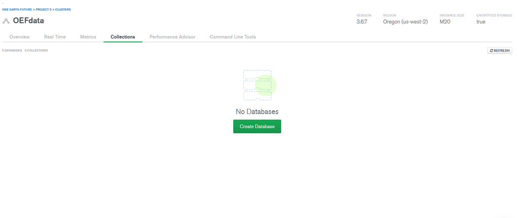

Empty atlas database

```r
library(mongolite)

#find cluster url with username and password replaced with SCRAM credentials
url_path = 'mongodb+srv://<username here>:<password here>!@<cluster url>/admin'

#make connection object that specifies new database and collection (dataset)
mongo1 <- mongo(collection = "EV_Forecast Data (1975 - 2018)", db = "OEFR",
              url = url_path,
              verbose = TRUE)

#show commands for connection
mongo1
```

```
## <Mongo collection> 'EV_Forecast Data (1975 - 2018)'
##  $aggregate(pipeline = "{}", options = "{\"allowDiskUse\":true}", handler = NULL, pagesize = 1000, iterate = FALSE)
##  $count(query = "{}")
##  $disconnect(gc = TRUE)
##  $distinct(key, query = "{}")
##  $drop()
##  $export(con = stdout(), bson = FALSE, query = "{}", fields = "{}", sort = "{\"_id\":1}")
##  $find(query = "{}", fields = "{\"_id\":0}", sort = "{}", skip = 0, limit = 0, handler = NULL, pagesize = 1000)
##  $import(con, bson = FALSE)
##  $index(add = NULL, remove = NULL)
##  $info()
##  $insert(data, pagesize = 1000, stop_on_error = TRUE, ...)
##  $iterate(query = "{}", fields = "{\"_id\":0}", sort = "{}", skip = 0, limit = 0)
##  $mapreduce(map, reduce, query = "{}", sort = "{}", limit = 0, out = NULL, scope = NULL)
##  $remove(query, just_one = FALSE)
##  $rename(name, db = NULL)
##  $replace(query, update = "{}", upsert = FALSE)
##  $run(command = "{\"ping\": 1}", simplify = TRUE)
##  $update(query, update = "{\"$set\":{}}", filters = NULL, upsert = FALSE, multiple = FALSE)
```

Use the **$insert** command to store the data in your Atlas collection.

```r
mongo1$drop()
mongo1$insert(ev_df)
```

```
##
Processed 1000 rows...
Processed 2000 rows...
Complete! Processed total of 2263 rows.
```

```
## List of 5
##  $ nInserted  : num 2263
##  $ nMatched   : num 0
##  $ nRemoved   : num 0
##  $ nUpserted  : num 0
##  $ writeErrors: list()
```

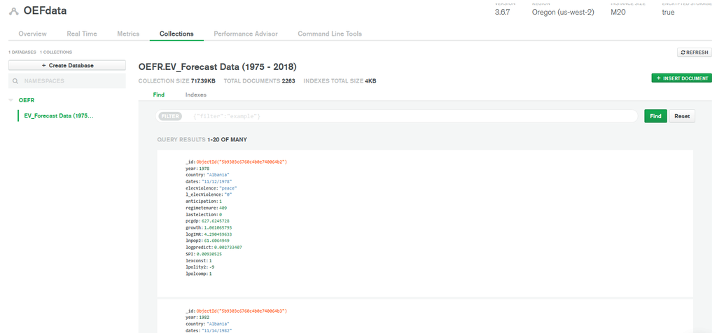

Our election violence data (collection) is now housed in our OEFR database